# Clase 4: Visualización de datos en R

Taquerías de México — DENUE, INEGI

Introducción a la Programación para Economistas

2026-07-02

```r
library(tidyverse)
library(patchwork)
library(readxl)
```

# Los datos: DENUE

El **DENUE** (Directorio Estadístico Nacional de Unidades Económicas) es el registro oficial del INEGI de todos los establecimientos económicos en México. En particular, el archivo que utilizaremos contiene todos los establecimientos que tienen la palabra “taqueria” en su nombre.

```r
denue_raw <- read_csv("datos/taquerias.csv",
                      locale = locale(encoding = "latin1"))
```

Los **encodings** son sistemas para convertir texto en números. El problema: existen varios estándares, y si usas el equivocado los acentos y ñ salen como símbolos raros.

Los más comunes que van a encontrar:

- **UTF-8** — el estándar moderno, lo que usa R por defecto
- **Latin1** — muy común en archivos del gobierno mexicano (como el DENUE)
- **Windows-1252** — archivos generados en Windows, parecido a Latin1

Si ves `é` o `ñ` donde debería haber acentos, el archivo está en Latin1 y R lo está leyendo como UTF-8.

## ¿Cómo detectarlo?

```r
library(readr)
guess_encoding("datos/taquerias.csv")
```

```
## # A tibble: 2 × 2
##   encoding   confidence
##   <chr>           <dbl>
## 1 ISO-8859-1       0.66
## 2 ISO-8859-2       0.38
```

# Limpieza rápida

Seleccionamos solo las columnas útiles y les damos nombres manejables:

```r
taquerias <- denue_raw %>%
  select(
    id          = ID,
    nombre      = `Nombre de la Unidad Económica`,
    actividad   = `Nombre de clase de la actividad`,
    estrato     = `Descripcion estrato personal ocupado`,
    colonia     = `Nombre de asentamiento humano`,
    municipio   = Municipio,
    entidad     = `Entidad federativa`,
    tipo        = `Tipo de establecimiento`,
    lat         = Latitud,
    lon         = Longitud,
    fecha_inc   = `Fecha de incorporación al DENUE`
  ) %>%
  mutate(
    año_inc = str_sub(fecha_inc, 1, 4) %>% as.integer(),
    estrato = fct_relevel(estrato,
      "0 a 5 personas", "6 a 10 personas", "11 a 30 personas",
      "31 a 50 personas", "51 a 100 personas", "101 a 250 personas"))
```

Con esto ya podemos trabajar. Ahora sí, a graficar.

# ¿Para qué sirve una gráfica?

Antes de escribir una sola línea de `ggplot2`, hay que preguntarse: **¿cuál es el mensaje?**

Una gráfica es un **mapeo de datos a elementos visuales**. Cada punto, barra, color o forma debe corresponder a algo en los datos. Si hay color decorativo, sobra. Si hay un eje que no representa nada, engaña.

Tres preguntas antes de empezar:

1. **¿Cuál es el mensaje?** Escríbelo en una oración. Si no puedes, la gráfica no está lista.
2. **¿Podría ser una tabla o una oración?** “Hay 10,984 taquerías en el dataset” no necesita gráfica.
3. **¿Puede el lector señalar cada elemento y decir qué significa?**

# Gramática de gráficos

`ggplot2` estructura toda gráfica en tres piezas:

- **Datos**: el objeto que contiene la información
- **Mapeos** (`aes()`): qué variable va a qué elemento visual (x, y, color, tamaño, forma)
- **Geometría** (`geom_*`): cómo se dibujan esos mapeos

```r
# ── Manipulación de datos ─────────────────────────────────────────────────────

top10_municipios <- taquerias %>%
  count(municipio, sort = TRUE) %>%   # cuenta filas por municipio → crea columna "n"
  slice_head(n = 10)                  # se queda con los 10 más grandes

top10_municipios   # siempre vale la pena ver qué tienes antes de graficar
```

```
## # A tibble: 10 × 2
##    municipio         n
##    <chr>         <int>
##  1 Guadalajara     334
##  2 Monterrey       247
##  3 Benito Juárez   244
##  4 Zapopan         225
##  5 Cuauhtémoc      219
##  6 Mérida          201
##  7 León            200
##  8 Puebla          191
##  9 Tijuana         190
## 10 Culiacán        188
```

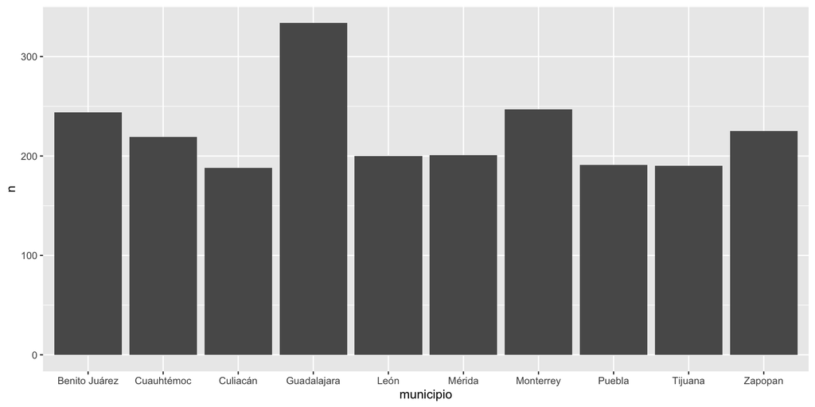

```r
# ── Gráfica ───────────────────────────────────────────────────────────────────

ggplot(data    = top10_municipios,       # los datos que acabamos de preparar
       mapping = aes(x = municipio,      # eje horizontal: nombre del municipio
                     y = n)) +           # eje vertical: el conteo que calculamos arriba
  geom_col()                             # geom_col = barras, donde la altura es y
```

Funciona, pero es difícil de leer. Lo vamos a mejorar capa por capa.

# Construir una gráfica capa por capa

Mensaje: **¿Cuales demarcaciones de la CDMX estan en el top 10 de taquerias a nivel nacional?**

## Paso 1: ordenar

```r
# ── Manipulación de datos ─────────────────────────────────────────────────────

top10_municipios <- taquerias %>%
  count(municipio, sort = TRUE) %>%       # cuenta taquerías por municipio → columna "n"
  slice_head(n = 10) %>%                  # top 10
  mutate(
    municipio = fct_reorder(municipio, n) # convierte municipio a factor ordenado por n
  )                                       # sin esto las barras salen en orden alfabético

top10_municipios
```

```
## # A tibble: 10 × 2
##    municipio         n
##    <fct>         <int>
##  1 Guadalajara     334
##  2 Monterrey       247
##  3 Benito Juárez   244
##  4 Zapopan         225
##  5 Cuauhtémoc      219
##  6 Mérida          201
##  7 León            200
##  8 Puebla          191
##  9 Tijuana         190
## 10 Culiacán        188
```

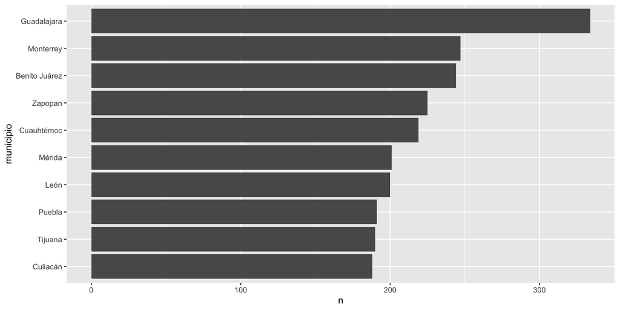

```r
# ── Gráfica ───────────────────────────────────────────────────────────────────

ggplot(data    = top10_municipios,
       mapping = aes(x = n,           # eje horizontal: el conteo
                     y = municipio)) + # eje vertical: el municipio (ya ordenado)
  geom_col()                    # barras horizontales — más fácil de leer nombres largos
```

`fct_reorder` ordena las barras de menor a mayor según `n`. Sin esto, aparecen en orden alfabético, que no dice nada al lector.

## Paso 2: agregar un mapeo que aporte información

Para responder la pregunta necesitamos saber qué municipios son de la CDMX. Esa información ya está en los datos — en la columna `entidad` — pero no la tenemos en `top10_municipios` porque solo contamos por municipio.

La solución es unir dos tablas usando `left_join`.

### ¿Qué es un join?

Un join une dos tablas usando una columna en común como llave. Primero veamos las dos tablas que vamos a unir:

```r
# tabla izquierda — el top 10 que ya teníamos
head(top10_municipios,2)
```

```
## # A tibble: 2 × 2
##   municipio       n
##   <fct>       <int>
## 1 Guadalajara   334
## 2 Monterrey     247
```

```r
# tabla derecha — cada municipio con su entidad
# distinct() elimina duplicados: sin esto tendríamos una fila por taquería
municipio_entidad <- taquerias %>%
  distinct(municipio, entidad)

head(municipio_entidad,5)
```

```
## # A tibble: 5 × 2
##   municipio                 entidad
##   <chr>                     <chr>
## 1 Aguascalientes            AGUASCALIENTES
## 2 San José de Gracia        AGUASCALIENTES
## 3 Pabellón de Arteaga       AGUASCALIENTES
## 4 San Francisco de los Romo AGUASCALIENTES
## 5 Jesús María               AGUASCALIENTES
```

`left_join` pega la tabla derecha sobre la izquierda usando `municipio` como llave. **La tabla de la izquierda manda**: se conservan todas sus filas y se les agregan las columnas de la derecha.

```r
# resultado del join: top10 + columna entidad
top10_municipios %>%
  left_join(municipio_entidad, by = "municipio")
```

```
## # A tibble: 15 × 3
##    municipio         n entidad
##    <chr>         <int> <chr>
##  1 Guadalajara     334 JALISCO
##  2 Monterrey       247 NUEVO LEÓN
##  3 Benito Juárez   244 CIUDAD DE MÉXICO
##  4 Benito Juárez   244 GUERRERO
##  5 Benito Juárez   244 QUINTANA ROO
##  6 Benito Juárez   244 SONORA
##  7 Zapopan         225 JALISCO
##  8 Cuauhtémoc      219 COLIMA
##  9 Cuauhtémoc      219 CHIHUAHUA
## 10 Cuauhtémoc      219 CIUDAD DE MÉXICO
## 11 Mérida          201 YUCATÁN
## 12 León            200 GUANAJUATO
## 13 Puebla          191 PUEBLA
## 14 Tijuana         190 BAJA CALIFORNIA
## 15 Culiacán        188 SINALOA
```

Ahora que tenemos `entidad`, podemos crear la columna `es_cdmx` y usarla como mapeo de color:

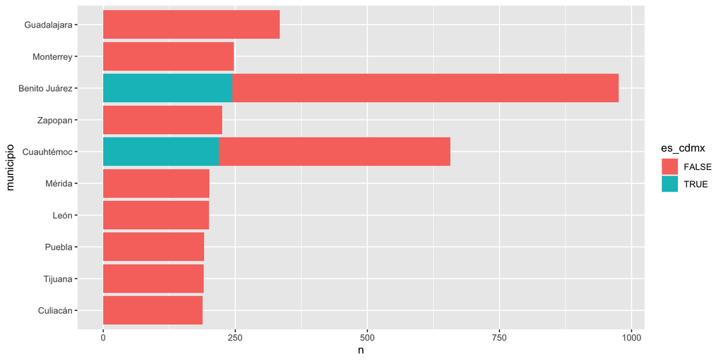

```r
top10_municipios <- taquerias %>%
  count(municipio, sort = TRUE) %>%
  slice_head(n = 10) %>%
  left_join(municipio_entidad, by = "municipio") %>%
  mutate(
    municipio = fct_reorder(municipio, n),
    es_cdmx   = entidad == "CIUDAD DE MÉXICO"
  )

# fill es un tercer mapeo: cada barra se colorea según es_cdmx
ggplot(top10_municipios, aes(x = n, y = municipio, fill = es_cdmx)) +
  geom_col()
```

```r
# verificamos el problema — Benito Juárez aparece en más de un estado
municipio_entidad %>%
  filter(municipio == "Benito Juárez")
```

```
## # A tibble: 4 × 2
##   municipio     entidad
##   <chr>         <chr>
## 1 Benito Juárez CIUDAD DE MÉXICO
## 2 Benito Juárez GUERRERO
## 3 Benito Juárez QUINTANA ROO
## 4 Benito Juárez SONORA
```

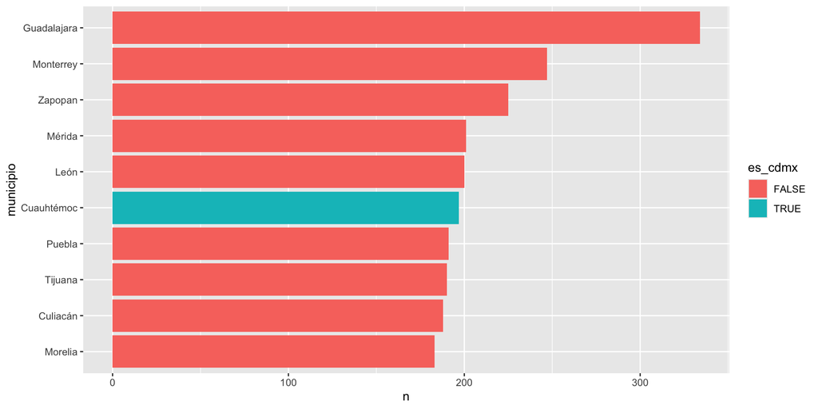

```r
# contamos por municipio Y entidad desde el inicio — así no hay duplicados
top10_municipios <- taquerias %>%
  count(municipio, entidad, sort = TRUE) %>%   # una fila por combinación única
  slice_head(n = 10) %>%
  mutate(
    municipio = fct_reorder(municipio, n),
    es_cdmx   = entidad == "CIUDAD DE MÉXICO"
  )


ggplot(top10_municipios, aes(x = n, y = municipio, fill = es_cdmx)) +
  geom_col()
```